# Diabete Prediction

2023-07-31

## Otimização do modelo preditivo de ocorrência de Diabetes

### Obtenção de dados

**Conjunto de Dados do Repositório de Machine Learning da UCI / Kaggle**

O conjunto de dados utilizado pode ser encontrado no Kaggle: https://www.kaggle.com/datasets/uciml/pima-indians-diabetes-database

O conjunto de dados consiste em diversas variáveis de previsão médica e uma variável de destino, resultado. As variáveis preditoras, dados de entrada, incluem o número de gestações que a paciente teve, seu IMC, nível de insulina, idade e assim por diante.

Considere a variável **Resultado** com valor 1 para True e 0 para False

**Informações sobre os atributos**

- Pregnancies / Gravidez - Número de gestações
- Glucose / Glicose - Concentração de glicose no plasma duas horas em um teste oral de tolerância à glicose
- Blood Pressure / Pressão sanguínea - Pressão arterial diastólica (mm Hg)
- SkinThickness / Espessura da pele - Tríceps espessura da dobra da pele (mm)
- Isulin / Insulina - Insulina sérica de 2 horas (mu U / ml)
- BMI / IMC - Índice de massa corporal (peso em kg / (altura em m) ^ 2)
- Diabetes Pedigree Function / Função de pedigree do diabéticos - Função pedigree do diabéticos
- Age / Idade - Anos
- Outcome / Resultado - A variável de classe (0 ou 1)

```r
# importando as bibliotecas necessárias para construir o modelo
library(randomForest)
library(dplyr)
library(ggplot2)
library(corrplot)
library(pROC)
```

## Análise Exploratória

Lendo o conjundo de dados (dataset) para a construção de uma tabela, para explorar as **Variáveis Quantitativas**. Os valores de uma variável quantitativa são números que representam, geralmente, uma contagem ou uma medição. Um dataset é, geralmente representado em uma planilha, sendo cada linha uma observação de uma pessoa, e cada coluna um tipo de variável dessas observações.

**Importando os dados**

```r
# Carregando o conjunto de dados para o ambiente
df <- read.csv("diabetes.csv")
```

**A seguinte tabela mostra os dados que serão analisados, um breve resumo**

```r
# Vendo as primeiras linhas para visualizar brevemente
head(df, 4)
```

```
##   Pregnancies Glucose BloodPressure SkinThickness Insulin  BMI
## 1           6     148            72            35       0 33.6
## 2           1      85            66            29       0 26.6
## 3           8     183            64             0       0 23.3
## 4           1      89            66            23      94 28.1
##   DiabetesPedigreeFunction Age Outcome
## 1                    0.627  50       1
## 2                    0.351  31       0
## 3                    0.672  32       1
## 4                    0.167  21       0
```

```r
# Vendo as últimas linhas para visualizar brevemente
tail(df, 4)
```

```
##     Pregnancies Glucose BloodPressure SkinThickness Insulin  BMI
## 765           2     122            70            27       0 36.8
## 766           5     121            72            23     112 26.2
## 767           1     126            60             0       0 30.1
## 768           1      93            70            31       0 30.4
##     DiabetesPedigreeFunction Age Outcome
## 765                    0.340  27       0
## 766                    0.245  30       0
## 767                    0.349  47       1
## 768                    0.315  23       0
```

```r
# Vendo uma breve descrição dos dados
summary(df)
```

```
##   Pregnancies        Glucose      BloodPressure    SkinThickness
##  Min.   : 0.000   Min.   :  0.0   Min.   :  0.00   Min.   : 0.00
##  1st Qu.: 1.000   1st Qu.: 99.0   1st Qu.: 62.00   1st Qu.: 0.00
##  Median : 3.000   Median :117.0   Median : 72.00   Median :23.00
##  Mean   : 3.845   Mean   :120.9   Mean   : 69.11   Mean   :20.54
##  3rd Qu.: 6.000   3rd Qu.:140.2   3rd Qu.: 80.00   3rd Qu.:32.00
##  Max.   :17.000   Max.   :199.0   Max.   :122.00   Max.   :99.00
##     Insulin           BMI        DiabetesPedigreeFunction      Age
##  Min.   :  0.0   Min.   : 0.00   Min.   :0.0780           Min.   :21.00
##  1st Qu.:  0.0   1st Qu.:27.30   1st Qu.:0.2437           1st Qu.:24.00
##  Median : 30.5   Median :32.00   Median :0.3725           Median :29.00
##  Mean   : 79.8   Mean   :31.99   Mean   :0.4719           Mean   :33.24
##  3rd Qu.:127.2   3rd Qu.:36.60   3rd Qu.:0.6262           3rd Qu.:41.00
##  Max.   :846.0   Max.   :67.10   Max.   :2.4200           Max.   :81.00
##     Outcome
##  Min.   :0.000
##  1st Qu.:0.000
##  Median :0.000
##  Mean   :0.349
##  3rd Qu.:1.000
##  Max.   :1.000
```

Os valores próximos entre a média, moda e mediana explica a **Distribuição Normal** dos dados. Vemos no histograma abaixo a distribuição dos dados da coluna **BloofPressure** (Pressão Sanguínea).

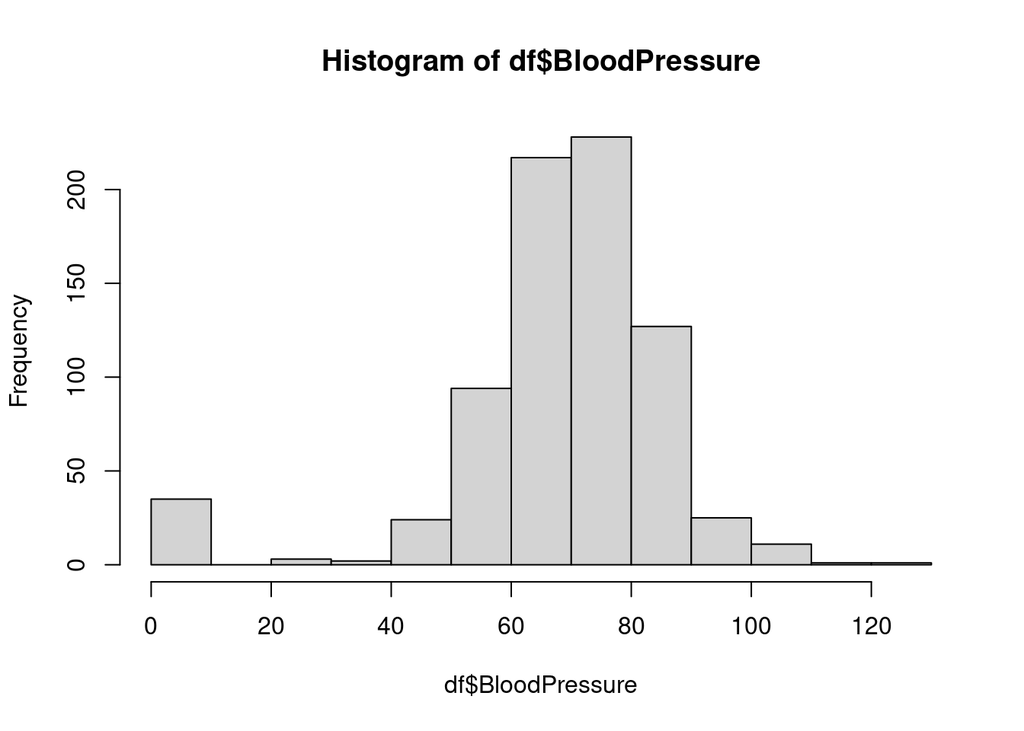

```r
hist(df$BloodPressure)
```

## Explorando os dados

```r
# Verificando o formato dos dados
cat(sprintf("Linhas: %s\nColunas: %s\n\n", nrow(df), ncol(df)))
```

```
## Linhas: 768
## Colunas: 9
```

```r
for (i in colnames(df)) {
    cat(sprintf("%s - %s\n",i, class(df[,i])))
}
```

```
## Pregnancies - integer
## Glucose - integer
## BloodPressure - integer
## SkinThickness - integer
## Insulin - integer
## BMI - numeric
## DiabetesPedigreeFunction - numeric
## Age - integer
## Outcome - integer
```

O nosso conjunto de dados contém 768 linhas e 9 colunas, a coluna **Resultado** (Outcome) é o nosso dado de saída, o que queremos prever, sendo 0 para os que não possuem e 1 para os que possuem o diabetes.

Vale lembrar que a qualidade dos dados está relacionada à quantidade de dados nulos, então iremos verificar se existem valores nulos no nosso conjunto de dados

```r
# Verificando se existem valores ausentes nos dados (N/A ou NaN)
for (i in colnames(df)) {
    cat(sprintf("%s - %s\n",i, sum(is.na(df[,i]))))
}
```

```
## Pregnancies - 0
## Glucose - 0
## BloodPressure - 0
## SkinThickness - 0
## Insulin - 0
## BMI - 0
## DiabetesPedigreeFunction - 0
## Age - 0
## Outcome - 0
```

Ao acabarmos de verificar, vemos que não existem valores nulos (N/A ou NaN), porém há também a possibilidade de existir valores ausentes iguais a 0 que seriam impossíveis

```r
# Verificando se existem dados ausentes
for (i in colnames(df)) {
    cat(sprintf("%s - %s\n",i, sum(df[,i]==0)))
}
```

```
## Pregnancies - 111
## Glucose - 5
## BloodPressure - 35
## SkinThickness - 227
## Insulin - 374
## BMI - 11
## DiabetesPedigreeFunction - 0
## Age - 0
## Outcome - 500
```

Como vemos nos dados há muitos valores ausentes impossíveis, como a Insulina, com 374 valores iguais a 0. Isso é impossível, pois a insulina não pode ser zero. Ao contrário de Gravidez, que não podemos tratar pois mesmo que possa haver valores que foram realmente colocados errados, é um valor possível, como não temos informações suficientes para saber como foi coletado os dados de gravidez, será uma variável que não será tratada nesse quesito, como também a coluna de Resultado

### Identificando e visualizando a correlação entre as variáveis

```r
# Visualizando a correlação entre as variáveis
cor(df)
```

```
##                          Pregnancies    Glucose BloodPressure SkinThickness
## Pregnancies               1.00000000 0.12945867    0.14128198   -0.08167177
## Glucose                   0.12945867 1.00000000    0.15258959    0.05732789
## BloodPressure             0.14128198 0.15258959    1.00000000    0.20737054
## SkinThickness            -0.08167177 0.05732789    0.20737054    1.00000000
## Insulin                  -0.07353461 0.33135711    0.08893338    0.43678257
## BMI                       0.01768309 0.22107107    0.28180529    0.39257320
## DiabetesPedigreeFunction -0.03352267 0.13733730    0.04126495    0.18392757
## Age                       0.54434123 0.26351432    0.23952795   -0.11397026
## Outcome                   0.22189815 0.46658140    0.06506836    0.07475223
##                              Insulin        BMI DiabetesPedigreeFunction
## Pregnancies              -0.07353461 0.01768309              -0.03352267
## Glucose                   0.33135711 0.22107107               0.13733730
## BloodPressure             0.08893338 0.28180529               0.04126495
## SkinThickness             0.43678257 0.39257320               0.18392757
## Insulin                   1.00000000 0.19785906               0.18507093
## BMI                       0.19785906 1.00000000               0.14064695
## DiabetesPedigreeFunction  0.18507093 0.14064695               1.00000000
## Age                      -0.04216295 0.03624187               0.03356131
## Outcome                   0.13054795 0.29269466               0.17384407
##                                  Age    Outcome
## Pregnancies               0.54434123 0.22189815
## Glucose                   0.26351432 0.46658140
## BloodPressure             0.23952795 0.06506836
## SkinThickness            -0.11397026 0.07475223
## Insulin                  -0.04216295 0.13054795
## BMI                       0.03624187 0.29269466
## DiabetesPedigreeFunction  0.03356131 0.17384407
## Age                       1.00000000 0.23835598
## Outcome                   0.23835598 1.00000000
```

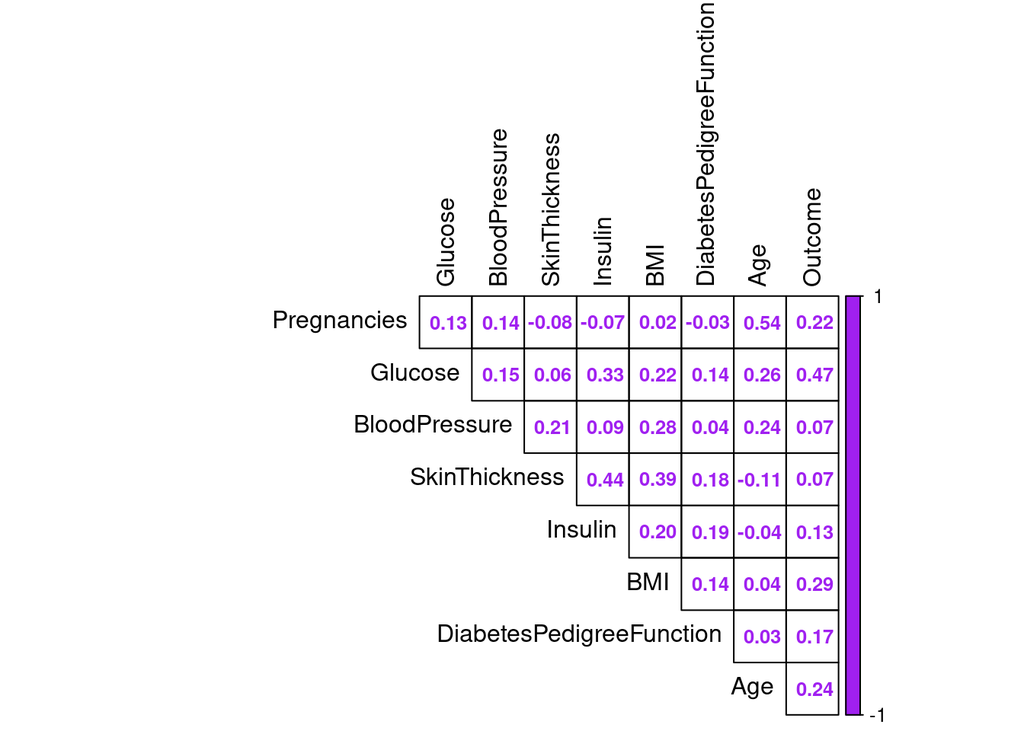

```r
# Criando um gráfico para a visualização da correlação
corrplot(cor(df), method="number", type="upper",
          diag=FALSE, tl.col="black", tl.cex=1, number.cex= 0.8,
          col="purple", addgrid = TRUE)
```

Esse processo é importante para vermos as variáveis mais relevantes no uso do modelo, lendo da seguinte maneira, correlação positiva é diretamente proporcional e correlação negativa é inversamente proporcional, porém é sempre bom lembrar que correlação não implica causalidade, não é porque uma variável é diretamente proporcional a outra que isso é uma causa do valor de uma sobre a outra

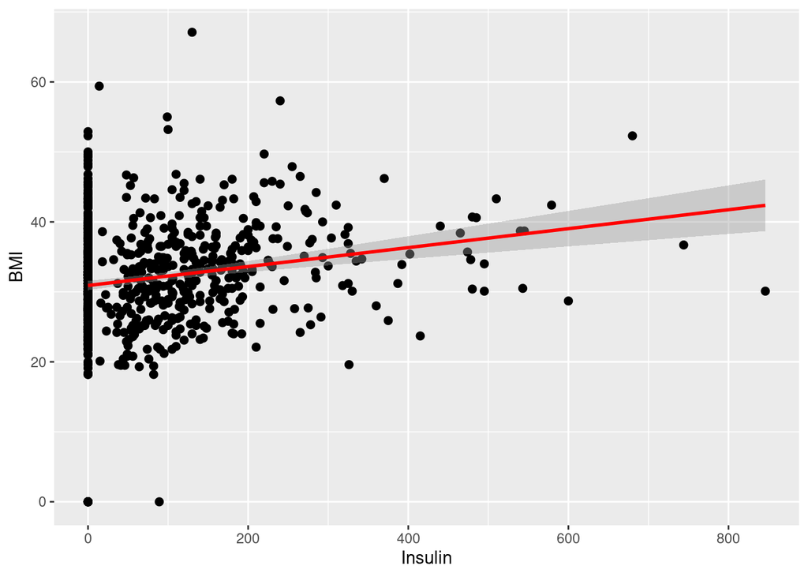

```r
ggplot(data = df, aes( x = Insulin, y = BMI)) +
    geom_point(size=2, col = "black")+
    geom_smooth(method="lm", col = "red")
```

Neste gráfico observamos os **Outliers**, um tipo deles, já mecionado antes, é os valores iguais a 0 que são impossíveis.

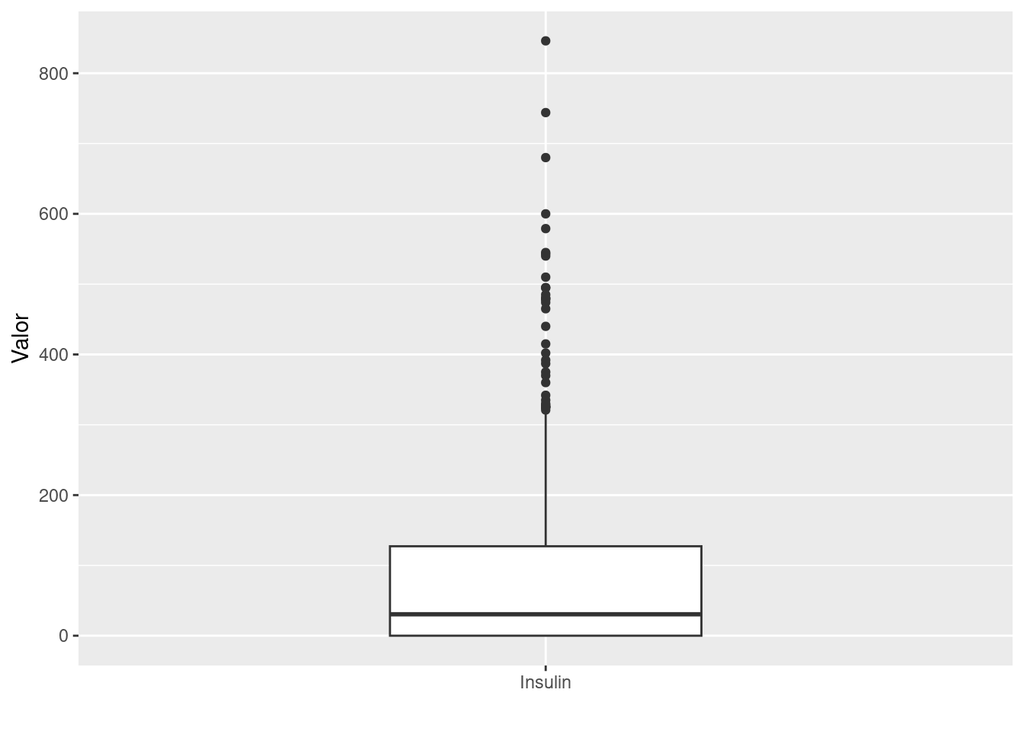

```r
ggplot(df, aes(x="Insulin", y=Insulin)) +
  geom_boxplot(width = 0.4) +
  xlab("") +
  ylab("Valor")
```

O **BoxPlot** ou diagrama de caixa é uma ferramenta utilizada para visualizar a distribuição dos dados e seus outliers, podendo facilmente notar os valores discrepantes.

## Preparando os dados

Primeiramente vamos converter o tipo dos números do conjunto de dados, para que o modelo entenda melhor os dados, ajudando a fazer previsões mais precisas.

```r
# Transformando os números em tipo 'numeric' no r
df[,-9] <- lapply(df[,-9], as.numeric) %>% data.frame

# Transformando a coluna resultado em tipo 'factor' no r com dois levels '0' e '1'
df[,9] <- as.factor(df[,9])
```

Agora vamos verificar o tipo dos dados para ver se concluiu a transformação com êxito

```r
# Verificando se os tipos dos dados foram transformados
for (i in colnames(df)) {
    cat(sprintf("%s - %s\n",i, class(df[,i])))
}
```

```
## Pregnancies - numeric
## Glucose - numeric
## BloodPressure - numeric
## SkinThickness - numeric
## Insulin - numeric
## BMI - numeric
## DiabetesPedigreeFunction - numeric
## Age - numeric
## Outcome - factor
```

Os dados faltantes que são iguais a 0 atrapalham o modelo em seu aprendizado, então o melhor a se fazer é tratar esses dados, em exemplo de dados que serão tratados são os valores iguais a 0 que são impossíveis como dito anteriormente, a Insulina, por exemplo. Os dados faltantes serão substituídos pela **mediana** dos mesmos dados, menos a variável Gravidez por conta de ela ser um valor possível

```r
# Criando uma variável com o nome de todas as colunas que serão tratadas
colunas <- c("Glucose", "BloodPressure", "SkinThickness", "Insulin", "BMI")

# Substituindo os dados da coluna de acordo com o level do Outcome, sendo uma mediana para vada valor do Outcome, '0' e '1'
for (i in colunas) {
    df[df['Outcome']==0,i] <- replace(df[df['Outcome']==0,i], df[df['Outcome']==0,i]==0, median(df[df[,i]!=0 & df['Outcome'] ==0,i]))
    df[df['Outcome']==1,i] <- replace(df[df['Outcome']==1,i], df[df['Outcome']==1,i]==0, median(df[df[,i]!=0 & df['Outcome'] ==1,i]))

}
```

Verificando novamente se existem dados ausentes, para ver se o tratamento de dados **ausentes** foi concluído

```r
for (i in colnames(df)) {
    cat(sprintf("%s - %s\n",i, sum(df[,i]==0)))
}
```

```
## Pregnancies - 111
## Glucose - 0
## BloodPressure - 0
## SkinThickness - 0
## Insulin - 0
## BMI - 0
## DiabetesPedigreeFunction - 0
## Age - 0
## Outcome - 500
```

Ao criar um modelo é importante definir uma semente, ela é importante para que veja a evolução do modelo de uma modo mais verdadeiro, a semente apenas interfere no modo que os dados são separados para criar o modelo, mas para que sempre seja o mesmo conjunto para treino e teste é importante a definição de uma semente, no nosso modelo iremos usar **42**

```r
# Definindo o valor da semente
set.seed(42)
```

Agora iremos definir os **indices** para definirmos os dados de **treino** e **teste**. Nosso conjunto de treino será de 70% e teste de 30% do conjunto dos dados.

```r
# Usando 70% dos dados para treino
indices <- sample(1:nrow(df), nrow(df)*0.7)

# Verificando o tamanho da amostra
cat(sprintf("O tamanho do conjunto de treino é de %s%s\n", round(length(indices)/nrow(df)*100, 2), "%"))
```

```
## O tamanho do conjunto de treino é de 69.92%
```

```r
cat(sprintf("O tamanho do conjunto de teste é de %s%s", round((nrow(df)-length(indices))/nrow(df)*100, 2), "%"))
```

```
## O tamanho do conjunto de teste é de 30.08%
```

Esses **indices** serviram para indicar a posição dos dados que serão de treino e teste. A variável **y** será separada, representando o **Outcome** do conjunto, a variável alvo do modelo.

```r
# Definindo o conjunto de dados para treino
treino_x <- df[indices, -9]
treino_y <- df[indices, 9]
# Definindo o conjunto de dados para teste
teste_x <- df[-indices, -9]
teste_y <- df[-indices, 9]
```

## Treinando os modelos e os comparando

Agora partiremos para a parte do treino do modelo, utilizaremos o modelo **randomForest**, um algorítimo que trabalha com classificações. Definindo 50 árvores de decisões para treinar o modelo.

```r
# Treinando o modelo com o conjunto de dados já tratado
modelo_rf <- randomForest(x = treino_x, y = treino_y, ntree = 50)
```

Como o modelo pronto iremos testar sua precisão no conjunto de teste, já separado anteriormente para este intuito.

```r
# Criando um conjunto de previsões utilizando o conjunto de teste
prevs <- predict(modelo_rf, newdata = teste_x)
```

A variável definida como **prevs** guarda os valores previdos pelo modelo e a variável **teste_y** guarda os valores verdadeiros para os dados, então para sabermos a precisão do modelo podemos comparar os dois conjuntos.

```r
# Definindo uma função para encontrar a precisão do modelo
prec <- (sum(prevs == teste_y) / length(prevs)) * 100
# Verificando essa precisão
cat(sprintf("A precisão do modelo randomForest é de %s%s", round(prec,2), "%"))
```

```
## A precisão do modelo randomForest é de 88.31%
```

```r
# Juntando os conjuntos separados anteriormente para treinarmos o modelo
Outcome <- as.numeric(levels(treino_y))[treino_y]
treino <- cbind(treino_x, Outcome)

Outcome <- as.numeric(levels(teste_y))[teste_y]
teste <- cbind(teste_x, Outcome)
```

Agora definiremos as colunas usadas para para predizer outra, no caso as colunas x serão usadas para predizer as colunas y, e transformaremos em uma fórmula usada como argumento para o teste do modelo, no formato de y ~ x.

```r
# Definindo as colunas necessárias
cols_x <- paste(colnames(treino[1:8]), collapse = " + ")
cols_y <- colnames(treino[9])

# Transformand em fórmula
formula <- as.formula(paste(cols_y, " ~ ", cols_x))
```

Com a formula em mãos iremos treinar o modelo.

```r
# Treinando o modelo
modelo_lr <- lm(formula, data = treino )
```

Novamente iremos verificar a precisão do modelo. Primeiro definindo o conjunto de predições.

```r
# Criando um conjunto de previsões utilizando o conjunto de teste
preds <- predict(modelo_lr, newdata = teste, type = "response")
```

```r
# Definindo uma função para encontrar a precisão do modelo
preci <- (sum(round(preds) == teste[,9]) / length(preds)) * 100
# Verificando essa precisão
cat(sprintf("A precisão do modelo Logistic Regression é de %s%s", round(preci,2), "%"))
```

```
## A precisão do modelo Logistic Regression é de 77.92%
```

Ao compararmos os dois modelos vemos uma grande diferença entre o modelo de **regressão linear** e o modelo de **árvore de decisão**. Para melhorar a visualização dessa diferença montaremos um gráfico mostrando a eficiência de cada modelo.

```r
# Definindo o roc score para cada modelo
roc_score_rf <- roc(teste_y, as.numeric(prevs))
roc_score_lr <- roc(teste[,9], as.numeric(round(preds)))
```

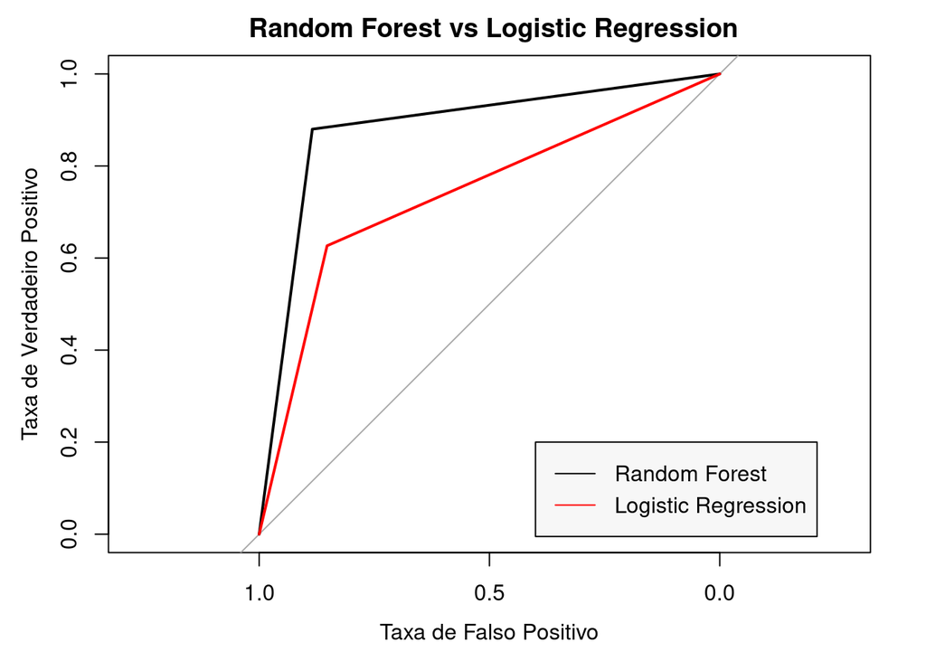

```r
plot(roc_score_rf,col = "black", main =" Random Forest vs Logistic Regression", ylab = "Taxa de Verdadeiro Positivo", xlab = "Taxa de Falso Positivo")
plot(roc_score_lr, col = "red", add = TRUE)
legend(0.4, 0.2, legend = c("Random Forest", "Logistic Regression"),  col=c("black", "red"), lty = 1, bg = "#f7f7f7")
```